# Análise Estatística do casos de cancer antes e depois do acidente de Chernobyl

Huggo Parcelly - Victor Paiva

2022-11-21

## Descrição do problema

O acidente com a usina nuclear de Chernobyl aconteceu no dia 26 de abril de 1986, no qual houve uma explosão em um reator, lançando material radioativo na atmosfera. A radiação logo se espalhou pelo o mundo, contudo as consequências foram mais profundas sobretudo para três países: Ucrânia, Bielorrússia e Rússia.

Uma consequência grave do acidente foi o aumento dos casos de cancer, que será o objeto de estudo desse relatório. Para tal, utilizou-se um banco de dados que foi retirado a partir de um estudo com as populações das cidades de Gomel, Mogilev e Belarus, que são próximas ao acidente.

Para fins de estudos desse relatório, levantou-se a problemática para comparar as médias dos casos de cancer nos anos de 1985 e 1986, ou seja, antes e depois do acidente.

## População associada

Homens e mulheres das cidades de Gomel, Mogilev e Belarus

## Variáveis e tipos de interesse para pesquisa

- A variável em estudo é a quantidade de casos de cancer, na população das três cidades e é do tipo quantitiva discreta.

## Objetivos do estudo

### Objetivos gerais

Comparar as médias dos casos de cancer na população das três cidades, analisando os anos 1985 e 1986.

### Objetivos específicos

Realizou-se uma comparação das médias dos casos de cancer, por 100.000 pessoas, das cidades de Gomel, Mogilev e Belarus, nos anos de 1985 e 1986. O objetivo é verificar que houve um aumento na média dos casos e em quanto foi o aumento, através dos testes t student e do Man-whitney.

## Coleta de amostra

Foram realizadas 84 observações, sendo 42 no ano de 1985 e 42 no ano de 1986, período antes e depois do acidente de Chernobyl. Para esses dados foram observados as quantidades de casos, para 7 tipos de câncer, por 100.000 habitantes, homens e mulheres, em mesma proporção.

Os tipos de câncer observados foram colon, rim, pele, pulmão, pancreas, reto e tireoide.

## Análise Exploratória de Dados (EDA)

```r
  if(!require(magrittr)) install.packages("magrittr")
  library(magrittr)

  if(!require(dplyr)) install.packages("dplyr")
```

```r
  library(dplyr)

  if(!require(ggplot2)) install.packages("ggplot2")
  library(ggplot2)

  if(!require(readr)) install.packages("readr")
  library(readr)

  dados <- read_csv("cancer_before_and_after_Chernobyl_Belarus.csv")
  ## Dados antes do acidente
  before = subset(dados, dados$year == 1985)

  ## Dados depois do acidente
  after = subset(dados, dados$year == 1986)

  total_rate_before = sum(before$cases)
  total_rate_after = sum(after$cases)

  total_rate <- c(total_rate_before, total_rate_after)

  years <- c(1985,1986)

  df_total <- data.frame(years, total_rate)
```

## Grafico de barras para visualizar a relação de casos de cancer com o acidente nuclear de Chernobyl.

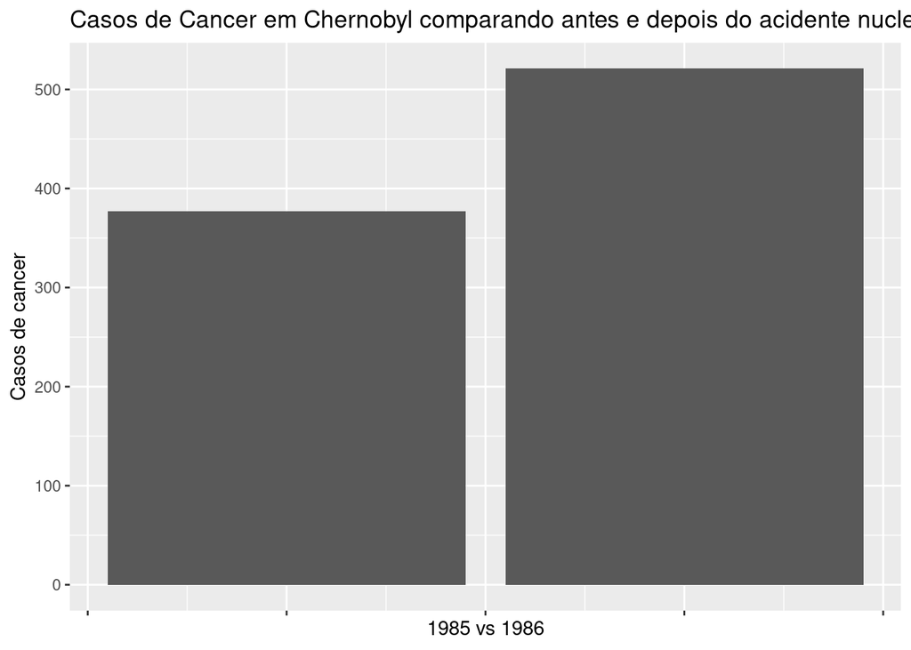

```r
  df_total %>% ggplot() + geom_col(aes(x=years, y=total_rate)) + ggtitle("Casos de Cancer em Chernobyl comparando antes e depois do acidente nuclear em Chernobyl no ano 1986") + ylab("Casos de cancer") + expand_limits(y=0) + xlab("1985 vs 1986") + theme(axis.text.x=element_blank())
```

```r
  perc_higher <- (total_rate_after - total_rate_before)/total_rate_before * 100
```

Houve um aumento de *38,27%*(perc_higher) nos casos de câncer.

## Histograma separado por ano.

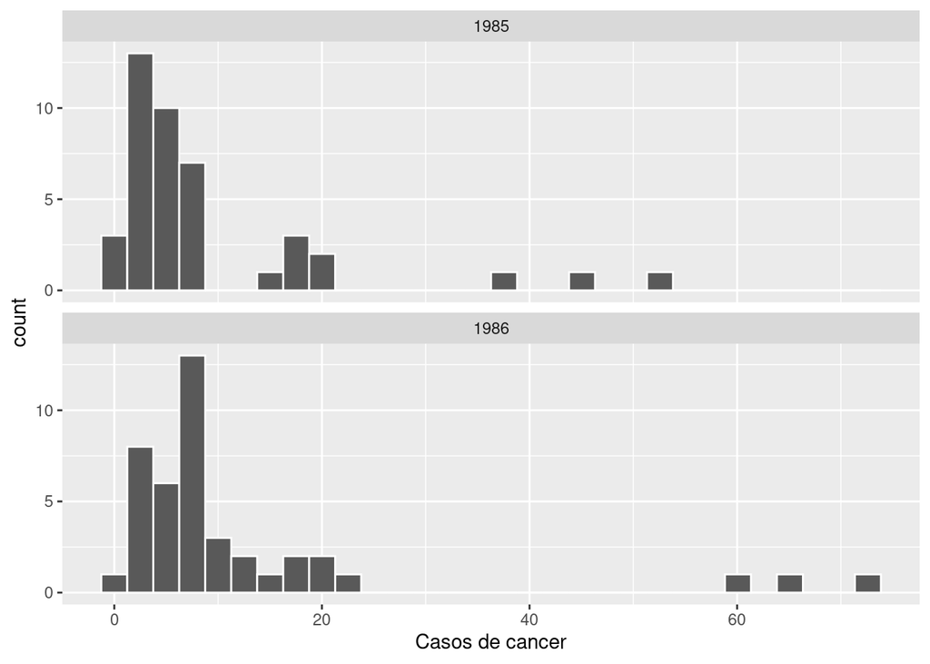

```r
  ggplot(data = dados, mapping = aes(x = cases)) +
geom_histogram(color = "white") + facet_wrap(~ year, ncol = 1) +
labs(x="Casos de cancer")
```

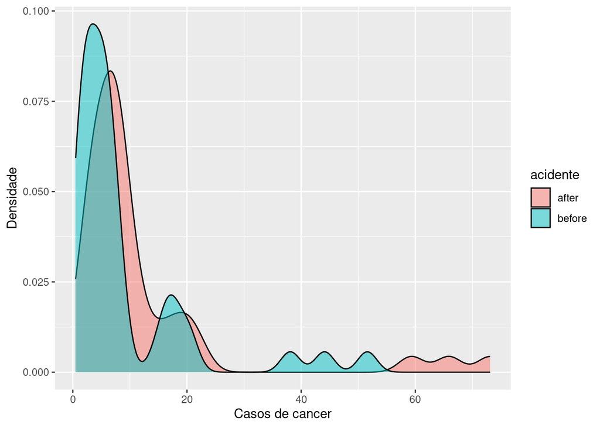

```r
dados1 <- transform( dados, acidente= ifelse(year==1985, "before", "after"))

dados1 %>% ggplot(aes(x = cases)) + geom_density(aes(fill = acidente),
alpha = 0.5 ) + labs(x="Casos de cancer", y="Densidade")
```

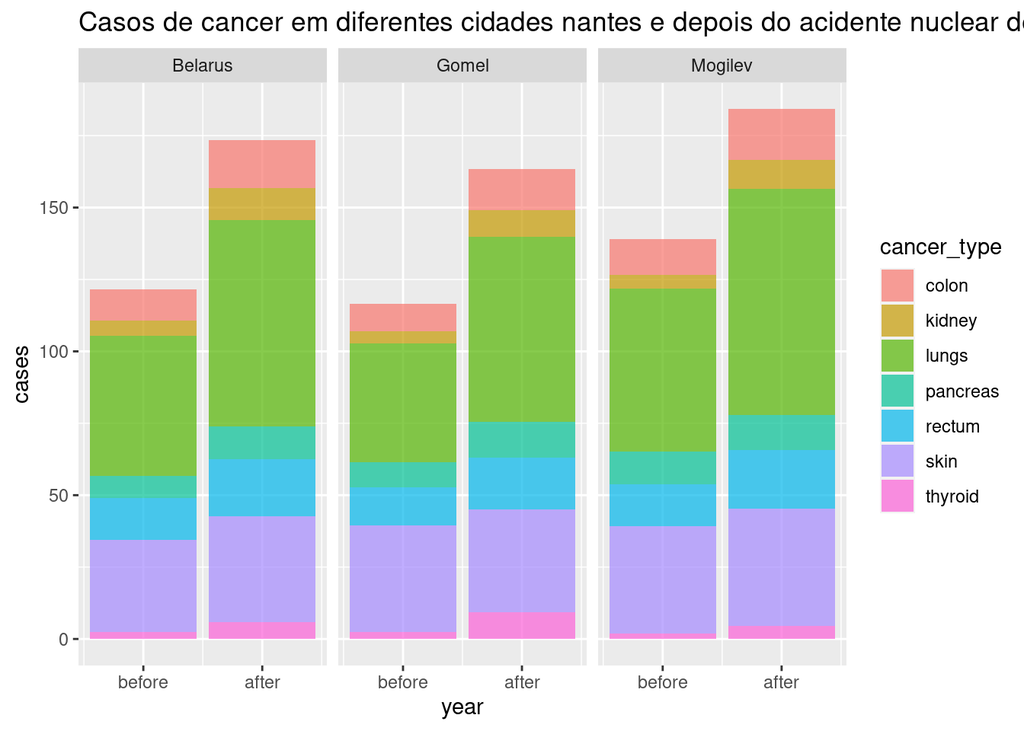

```r
## Gráfico dos casos de cancer nas três cidades, antes e depois do acidente
dados %>% ggplot() + geom_col(aes(year,cases, fill=cancer_type), alpha=0.7) + facet_grid(.~location) + scale_x_continuous(breaks = c(1985, 1986), labels = c("before", "after")) + ggtitle("Casos de cancer em diferentes cidades nantes e depois do acidente nuclear de Chernobyl")
```

```r
df_total
```

| years | total_rate |
| --- | --- |
| 1985 | 376.8 |
| 1986 | 521.0 |

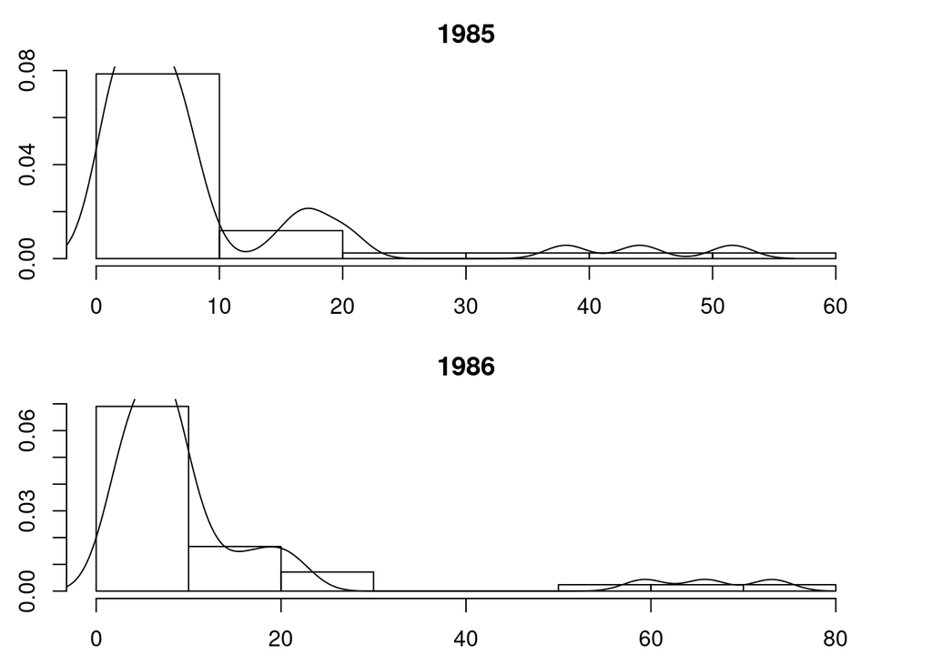

```r
x1 <- dados1$cases[dados1$acidente == "before"]
x2 <- dados1$cases[dados1$acidente == "after"]

par(mfrow = c(2,1), mar = rep(2.5, 4))

hist(x1, prob=TRUE, main = "1985")
lines(density(x1))

hist(x2, prob=TRUE, main = "1986", xlab = "Casos de cancer")
lines(density(x2))
```

## Inferências estatísticas

Verificamos a média de todos os casos de câncer nos dois anos, referentes a antes e depois do acidente.

Para comparar as médias utilizamos o test t student para amostras independentes

```r
  antes <- before$cases
  depois <- after$cases

  #test t

  t.test(antes, depois)
```

```
##
##  Welch Two Sample t-test
##
## data:  antes and depois
## t = -1.1319, df = 74.102, p-value = 0.2613
## alternative hypothesis: true difference in means is not equal to 0
## 95 percent confidence interval:
##  -9.477257  2.610590
## sample estimates:
## mean of x mean of y
##  8.971429 12.404762
```

Para comparar as medianas, utilizamos o test de Mann-Whitney

```r
  test_mann_whitney <- wilcox.test(cases ~ year, data=dados)
  test_mann_whitney
```

```
##
##  Wilcoxon rank sum test with continuity correction
##
## data:  cases by year
## W = 633.5, p-value = 0.02649
## alternative hypothesis: true location shift is not equal to 0
```

Tomando

H0: mediana dos casos em 1985 = mediana dos casos em 1986 -> p > 0.05 H1: mediana dos casos em 1985 != mediana dos casos em 1986 -> p <= 0.05

Portanto, como o valor de p < 0.05, então devemos considerar a hipótese alternativa e rejeitar a hipótese nula.

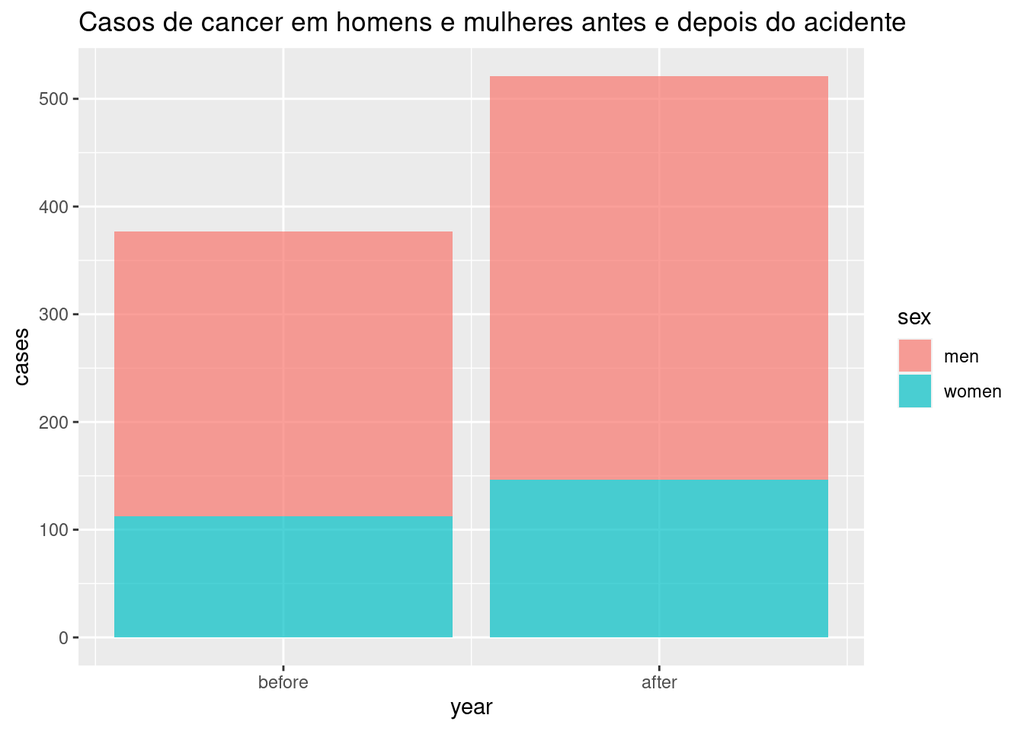

```r
  ## Casos de cancer em homens e mulheres, antes e depois do acidente
dados %>% ggplot() + geom_col(aes(year, cases, fill=sex), alpha=0.7) + scale_x_continuous(breaks = c(1985, 1986), labels = c("before", "after"))  + ggtitle("Casos de cancer em homens e mulheres antes e depois do acidente")
```

```r
## Dados de homens antes e depois do acidente
before = subset(dados, dados$year == 1985)
after = subset(dados, dados$year == 1986)

## Homens antes
before_men = subset(before, sex == 'men')
total_rate_before_men = sum(before_men$cases)

## Homens depois
after_men = subset(after, sex == 'men')
total_rate_after_men = sum(after_men$cases)

## Mulheres antes
before_women = subset(before, sex == 'women')
total_rate_before_women = sum(before_women$cases)

## Mulheres depois
after_women = subset(after, sex == 'women')
total_rate_after_women = sum(after_women$cases)


## Porcentagem de aumento de casos em homens e mulheres
total_rate_men <- c(total_rate_before_men, total_rate_after_men)
total_rate_women <- c(total_rate_before_women, total_rate_after_women)

perc_higher_men <- (total_rate_after_men - total_rate_before_men)/total_rate_before_men * 100
perc_higher_men
```

```
## [1] 41.91594
```

```r
perc_higher_women <- (total_rate_after_women - total_rate_before_women)/total_rate_before_women * 100
perc_higher_women
```

```
## [1] 29.72493
```

O aumento percentual do número de casos em homens é de *41.92%* e em mulheres é de *29.72%*

De acordo com os dados, o aumento percentual no número de casos em homens se mostrou maior que em mulheres, indicando que os homens foram mais propensos a contrair câncer que as mulheres.

O que podemos concluir é que após o acidente na usina nuclear de Chernobyl, houve um aumento nos casos de câncer nas cidades próximas. Os dados mostraram uma maior ocorrência de câncer em homens.